# Notebook

### Web Information Retrieval and Data Mining - Assignment 3

```
Student: van Gastel, Rob (1387952)
```

#### Answer 1.1, Baseline (4p)

- Dense network, at least 3 layers, shaped like a pyramid
  - Last layer: 10 nodes, sigmoid.
  - Loss: categorical cross-entropy. Metric: accuracy
- No preprocessing, regularization. Get at least 70% accuracy.
- Explain design decisions. Discuss performance.
  - Does it overfit (large/growing gap between loss and val_loss)?

[output not shown]

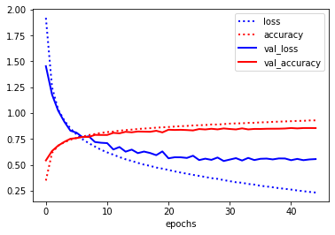

```
Model: "sequential_5"
_________________________________________________________________
Layer (type)                 Output Shape              Param #
=================================================================
reshape_5 (Reshape)          (None, 3072)              0
_________________________________________________________________
dense_16 (Dense)             (None, 2048)              6293504
_________________________________________________________________
leaky_re_lu_9 (LeakyReLU)    (None, 2048)              0
_________________________________________________________________
dense_17 (Dense)             (None, 1024)              2098176
_________________________________________________________________
leaky_re_lu_10 (LeakyReLU)   (None, 1024)              0
_________________________________________________________________
dense_18 (Dense)             (None, 512)               524800
_________________________________________________________________
leaky_re_lu_11 (LeakyReLU)   (None, 512)               0
_________________________________________________________________
dense_19 (Dense)             (None, 10)                5130
=================================================================
Total params: 8,921,610
Trainable params: 8,921,610
Non-trainable params: 0
_________________________________________________________________
None
def build_model_1_1():
    model = models.Sequential()
    model.add(layers.Reshape((3072,), input_shape=(32,32,3)))
    model.add(layers.Dense(2048))
    model.add(layers.LeakyReLU(alpha=0.05))
    model.add(layers.Dense(1024))
    model.add(layers.LeakyReLU(alpha=0.05))
    model.add(layers.Dense(512))
    model.add(layers.LeakyReLU(alpha=0.05))
    model.add(layers.Dense(10, activation='softmax'))
    # adag = optimizers.Adagrad(lr=0.01) or
    sgd = optimizers.SGD(lr=0.001, decay=1e-6, momentum=0.9, nesterov=True)
    model.compile(optimizer=sgd,
                  loss='categorical_crossentropy',
                  metrics=['accuracy'])
    return model
```

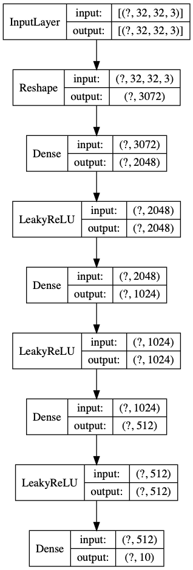

#### Answer 1.2, Preprocess (2p)

- Convert images to greyscale, other preprocessing optional.
  - Input shape should be (32,32,1)
- Explain design decisions. Is it better? Why (not)?
  - Color information is likely not so useful for classification. Greyscale makes the network smaller, less parameters to learn, less likely to overfit.

[output not shown]

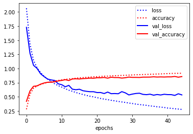

```
Model: "sequential_7"
_________________________________________________________________
Layer (type)                 Output Shape              Param #
=================================================================
reshape_7 (Reshape)          (None, 1024)              0
_________________________________________________________________
dense_24 (Dense)             (None, 2048)              2099200
_________________________________________________________________
leaky_re_lu_15 (LeakyReLU)   (None, 2048)              0
_________________________________________________________________
dense_25 (Dense)             (None, 1024)              2098176
_________________________________________________________________
leaky_re_lu_16 (LeakyReLU)   (None, 1024)              0
_________________________________________________________________
dense_26 (Dense)             (None, 512)               524800
_________________________________________________________________
leaky_re_lu_17 (LeakyReLU)   (None, 512)               0
_________________________________________________________________
dense_27 (Dense)             (None, 10)                5130
=================================================================
Total params: 4,727,306
Trainable params: 4,727,306
Non-trainable params: 0
_________________________________________________________________
None
def build_model_1_2():
    model = models.Sequential()
    model.add(layers.Reshape((1024,), input_shape=(32,32,1)))
    model.add(layers.Dense(2048))
    model.add(layers.LeakyReLU(alpha=0.05))
    model.add(layers.Dense(1024))
    model.add(layers.LeakyReLU(alpha=0.05))
    model.add(layers.Dense(512))
    model.add(layers.LeakyReLU(alpha=0.05))
    model.add(layers.Dense(10, activation='softmax'))
    # adag = optimizers.Adagrad(lr=0.1) # or
    sgd = optimizers.SGD(lr=0.001, decay=1e-6, momentum=0.9, nesterov=True)
    model.compile(optimizer=sgd,
                  loss='categorical_crossentropy',
                  metrics=['accuracy'])
    return model
```

#### Answer 1.3, Tune (4p)

- Regularize the model. What works best?
  - Should consider batch normalization, dropout, l1/l2 regularization (or Nesterov)
- Tune other hyperparameters (e.g. learning rate, batch size,...) as you see fit.
  - At least consider tuning learning rate, ideally also momentum, decay, other optimizers
- Explain your findings and final design decisions. Discuss the results.
  - Should be better, at least it shouldn't overfit

[output not shown]

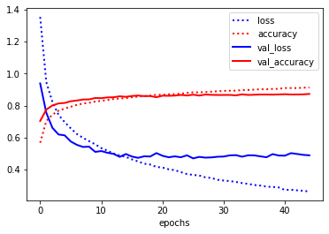

```
def build_model_1_3():
    model = models.Sequential()
    model.add(layers.Reshape((1024,), input_shape=(32,32,1)))
    model.add(layers.BatchNormalization())
    model.add(layers.Dropout(0.1))
    model.add(layers.Dense(2048))
    model.add(layers.LeakyReLU(alpha=0.05))
    model.add(layers.BatchNormalization())
    model.add(layers.Dropout(0.1))
    model.add(layers.Dense(1024))
    model.add(layers.LeakyReLU(alpha=0.05))
    model.add(layers.BatchNormalization())
    model.add(layers.Dropout(0.1))
    model.add(layers.Dense(512))
    model.add(layers.LeakyReLU(alpha=0.05))
    model.add(layers.BatchNormalization())
    model.add(layers.Dropout(0.1))
    model.add(layers.Dense(10, activation='softmax'))
    # adag = optimizers.Adagrad(lr=0.1) # or
    sgd = optimizers.SGD(lr=0.01, decay=1e-6, momentum=0.9, nesterov=True)
    model.compile(optimizer=sgd,
                  loss='categorical_crossentropy',
                  metrics=['accuracy'])
    return model
```

#### Answer 2.1, ConvNet (7p)

- Build a sequential ConvNet, get at least 90% accuracy.
  - Conv2D layers, input shape (32,32,1)
  - Consider using blocks of Conv2D layers with maxpooling in between
  - Use zero-padding in Conv2D layers because the images are small
  - At least one dense hidden layer and dense output layer (sigmoid)
  - Consider adding batch normalization, dropout
  - Consider small dropout rates in beginning, larger dropout rates later in network
  - Consider other optimizers and tuning learning rate, momentum,...
- Explain what you did and why (800 chars). Is it working well?
  - Should be quite elaborate and sensible

[output not shown]

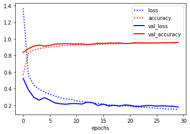

```
Model: "sequential_10"
_________________________________________________________________
Layer (type)                 Output Shape              Param #
=================================================================
conv2d_12 (Conv2D)           (None, 32, 32, 32)        320
_________________________________________________________________
batch_normalization_14 (Batc (None, 32, 32, 32)        128
_________________________________________________________________
conv2d_13 (Conv2D)           (None, 32, 32, 32)        9248
_________________________________________________________________
max_pooling2d_6 (MaxPooling2 (None, 16, 16, 32)        0
_________________________________________________________________
batch_normalization_15 (Batc (None, 16, 16, 32)        128
_________________________________________________________________
dropout_13 (Dropout)         (None, 16, 16, 32)        0
_________________________________________________________________
conv2d_14 (Conv2D)           (None, 16, 16, 64)        18496
_________________________________________________________________
batch_normalization_16 (Batc (None, 16, 16, 64)        256
_________________________________________________________________
conv2d_15 (Conv2D)           (None, 16, 16, 64)        36928
_________________________________________________________________
max_pooling2d_7 (MaxPooling2 (None, 8, 8, 64)          0
_________________________________________________________________
batch_normalization_17 (Batc (None, 8, 8, 64)          256
_________________________________________________________________
dropout_14 (Dropout)         (None, 8, 8, 64)          0
_________________________________________________________________
conv2d_16 (Conv2D)           (None, 8, 8, 128)         73856
_________________________________________________________________
batch_normalization_18 (Batc (None, 8, 8, 128)         512
_________________________________________________________________
conv2d_17 (Conv2D)           (None, 8, 8, 128)         147584
_________________________________________________________________
max_pooling2d_8 (MaxPooling2 (None, 4, 4, 128)         0
_________________________________________________________________
batch_normalization_19 (Batc (None, 4, 4, 128)         512
_________________________________________________________________
dropout_15 (Dropout)         (None, 4, 4, 128)         0
_________________________________________________________________
```

[output cut: 51 more lines]

```
    model.add(layers.LeakyReLU(alpha=0.05))
    model.add(layers.BatchNormalization())

    model.add(layers.Dropout(0.5))

    model.add(layers.Dense(1024))
    model.add(layers.LeakyReLU(alpha=0.05))
    model.add(layers.BatchNormalization())

    model.add(layers.Dense(10, activation='softmax'))
    sgd = optimizers.SGD(lr=0.01, decay=1e-6, momentum=0.9, nesterov=True)
    model.compile(optimizer=sgd,
                  loss='categorical_crossentropy',
                  metrics=['accuracy'])
    return model
```

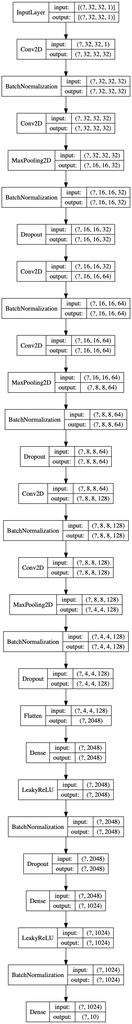

#### Answer 2.2, Data Augmentation (3p)

[output not shown]

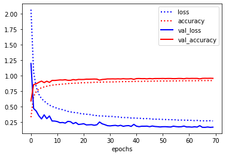

```
train_data_gen = ImageDataGenerator(
    rotation_range=30,
    shear_range=0.3,
    zoom_range=0.3,
    width_shift_range=0.05,
    height_shift_range=0.05,
    fill_mode='nearest',
)
```

#### Answer 3.1, Misclassifications (2p)

[output not shown]

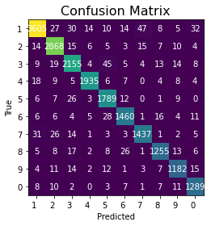

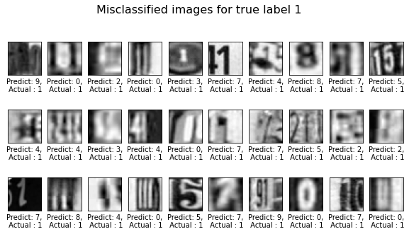

#### Answer 3.2, Activations (4p)

- Retrieve and visualize the activations for one example
- For every filter for different convolutional layers (at different depths in the network).
- Give an explanation. Is your model indeed learning something useful?
  - Should detect edges etc in first layers, higher-order object (e.g. interesting regions) in deeper layers.

[output not shown]

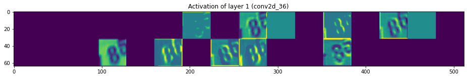

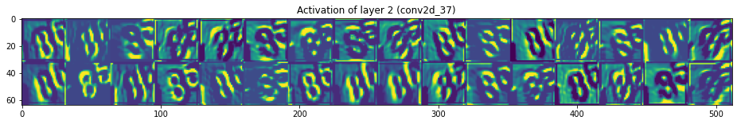

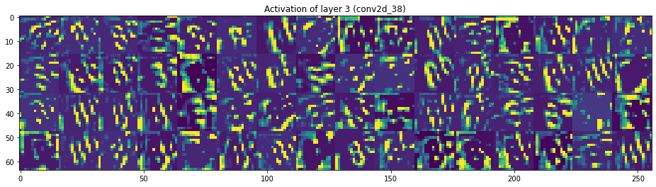

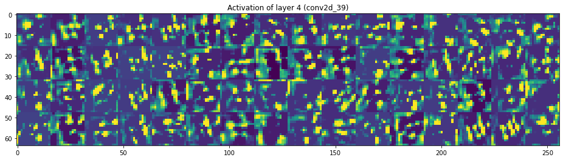

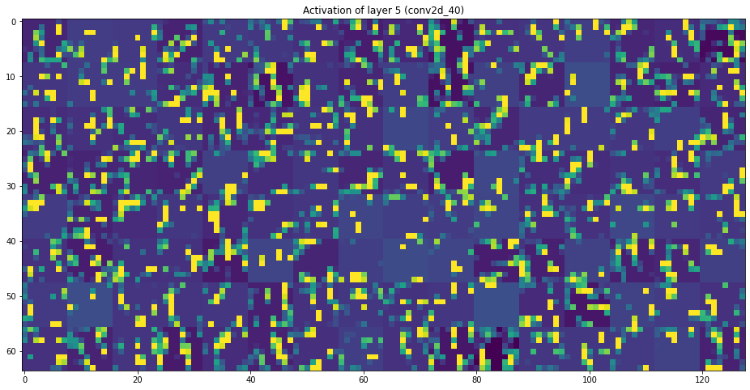

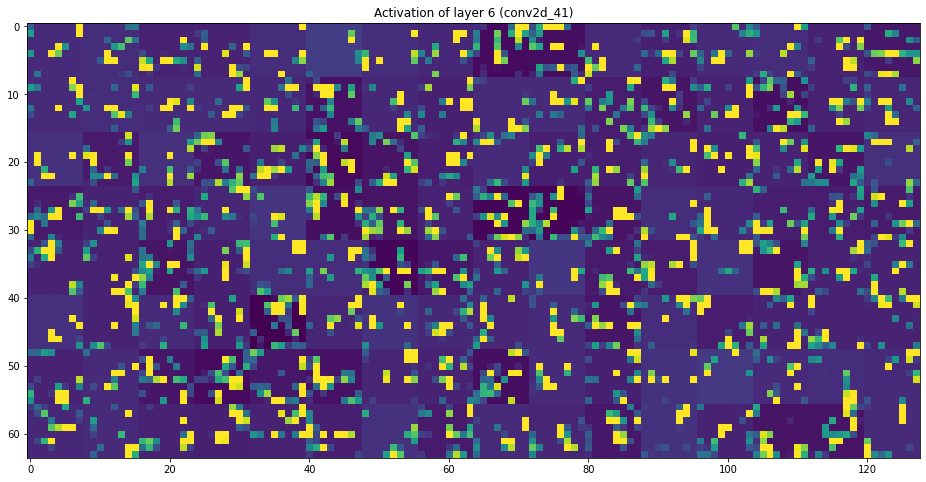

#### Answer 3.3, Class activation map (4p)

- Show a class activation map for your last convolutional layer
- Superimpose the activation map over the image, or plot side by side
  - Should make sense, detect interesting regions to classify the number

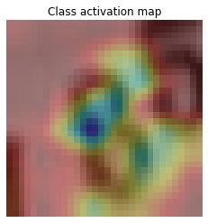

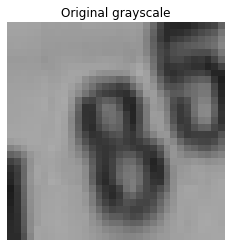

```
def plot_activation_map():
    # Example as seen in the slides about CNN
    K.clear_session()
    tf.compat.v1.disable_eager_execution()

    x_sample, y_sample = X_test[0], y_test[0]
    x_sample = rgb2gray(np.expand_dims(x_sample, axis=0))

    model = load_model_from_file(base_dir, "model_2_2")
    preds = model.predict(x_sample)

    argmax = np.argmax(preds[0])
    output = model.output[:, argmax]

    last_conv_layer  = model.get_layer("conv2d_41")
    grads = K.gradients(output, last_conv_layer.output)[0]
    pooled_grads = K.mean(grads, axis=(0, 1, 2))
    iterate = K.function([model.input], [pooled_grads, last_conv_layer.output[0]])
    pooled_grads_value, conv_layer_output_value = iterate([x_sample])

    for i in range(128):
        conv_layer_output_value[:, :, i] *= pooled_grads_value[i]

    heatmap = np.mean(conv_layer_output_value, axis=-1)
    heatmap = np.maximum(heatmap, 0)
    heatmap /= np.max(heatmap)

    image = np.concatenate((x_sample[0], x_sample[0], x_sample[0]), axis=2)
    heatmap = cv2.resize(heatmap, (image.shape[1], image.shape[0]))
    heatmap = np.uint8(255 * heatmap)
    heatmap = cv2.applyColorMap(heatmap, cv2.COLORMAP_JET)

    # Show superimposed image
    superimposed_img = heatmap * 0.3 + image * 255 * 0.7
    plt.imshow(superimposed_img.astype(np.uint8), vmax=255, vmin=0)
    plt.axis('off')
    plt.title('Class activation map')
    plt.show()

    # original grayscale image
    plt.imshow(image, cmap='gray')
    plt.axis('off')
    plt.title('Original grayscale')
    plt.show()
```

#### Answer 4.1, Fast feature extraction (5p)

- Import the VGG16 model, pretrained on ImageNet
- Freeze convolutional base, adds a dense layer
- Consider unfreezing the last few convolutional layers and evaluate whether that works better
  - Check if they do. It is very likely to help.
- Discuss the observed performance
  - Should get around 80% accuracy

[output not shown]

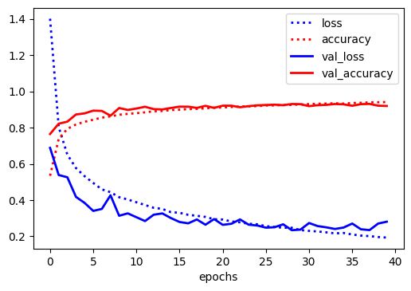

```
Model: "sequential_21"
_________________________________________________________________
Layer (type)                 Output Shape              Param #
=================================================================
vgg16 (Model)                (None, 1, 1, 512)         14714688
_________________________________________________________________
dropout_14 (Dropout)         (None, 1, 1, 512)         0
_________________________________________________________________
flatten_16 (Flatten)         (None, 512)               0
_________________________________________________________________
dense_46 (Dense)             (None, 2048)              1050624
_________________________________________________________________
leaky_re_lu_18 (LeakyReLU)   (None, 2048)              0
_________________________________________________________________
batch_normalization_17 (Batc (None, 2048)              8192
_________________________________________________________________
dropout_15 (Dropout)         (None, 2048)              0
_________________________________________________________________
dense_47 (Dense)             (None, 1024)              2098176
_________________________________________________________________
leaky_re_lu_19 (LeakyReLU)   (None, 1024)              0
_________________________________________________________________
batch_normalization_18 (Batc (None, 1024)              4096
_________________________________________________________________
dense_48 (Dense)             (None, 10)                10250
=================================================================
Total params: 17,886,026
Trainable params: 16,144,394
Non-trainable params: 1,741,632
_________________________________________________________________
None
def build_model_4_1():
    model = models.Sequential()
    base_model = VGG16(weights='imagenet', include_top=False, input_shape=(32, 32, 3))

    for i in range(0, len(base_model.layers)-8):
        base_model.layers[i].trainable = False
    model.add(base_model)

    model.add(layers.Dropout(0.5))

    model.add(layers.Flatten())
    model.add(layers.Dense(2048))
    model.add(layers.LeakyReLU(alpha=0.05))
    model.add(layers.BatchNormalization())

    model.add(layers.Dropout(0.5))

    model.add(layers.Dense(1024))
    model.add(layers.LeakyReLU(alpha=0.05))
    model.add(layers.BatchNormalization())

    model.add(layers.Dense(10, activation='softmax'))
    model.compile(optimizer='sgd',
                  loss='categorical_crossentropy',
                  metrics=['accuracy'])
    return model
```

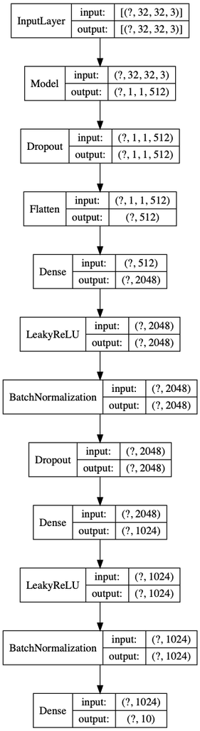

#### Answer 4.2, Embeddings (5p)

- Generate embeddings with the trained convolutional part of model_4_1 (without the dense layer)
- Embed the training and test data and store them to disk
- Build and evaluate a pipeline on the embedded data
  - Check if pipeline makes sense (e.g. use models that can handle many dimensions)
- Describe what you did and what you observed (max 800 chars).
  - Consider different models, preprocessing, tuning, etc.
  - Check performance (see original Submission.html) when in doubt. We did not run all the evaluations because it takes too long, and the output is ill-defined.

[output not shown]

```
Running time: 22.74 seconds
Last modified: May 26, 2020
scikit-learn version: 0.23.1
```